# 重賞レース予測レポート【レース終了】

作成日時: 2025/08/03 17:41:03

☞ [マニュアル(pdf)](https://ryutoro-galois.github.io/keiba-predictor/manual/manual.pdf)

☞ 過去5年の同一レース結果: [2024年](https://ryutoro-galois.github.io/keiba-predictor/report/PredResult_2024y_raceDate_20240727_20240728.html), [2023年](https://ryutoro-galois.github.io/keiba-predictor/report/PredResult_2023y_raceDate_20230729_20230730.html), [2022年](https://ryutoro-galois.github.io/keiba-predictor/report/PredResult_2022y_raceDate_20220730_20220731.html), [2021年](https://ryutoro-galois.github.io/keiba-predictor/report/PredResult_2021y_raceDate_20210725_20210725.html), [2020年](https://ryutoro-galois.github.io/keiba-predictor/report/PredResult_2020y_raceDate_20200726_20200726.html)

☞ 過去4週間の別レース結果: [1週前(7/27)](https://ryutoro-galois.github.io/keiba-predictor/report/PredResult_2025y_raceDate_20250727_20250727.html), [2週前(7/20)](https://ryutoro-galois.github.io/keiba-predictor/report/PredResult_2025y_raceDate_20250720_20250720.html), [3週前(7/13)](https://ryutoro-galois.github.io/keiba-predictor/report/PredResult_2025y_raceDate_20250713_20250713.html), [4週前(7/6)](https://ryutoro-galois.github.io/keiba-predictor/report/PredResult_2025y_raceDate_20250706_20250706.html)

☞ netkeiba: [アイビスサマーD(GⅢ)](https://race.netkeiba.com/race/result.html?race_id=202504020407&rf=race_submenu), [クイーンステークス(GⅢ)](https://race.netkeiba.com/race/result.html?race_id=202501010411&rf=race_submenu)

☞ レース結果(csv): [8/2-3](https://ryutoro-galois.github.io/keiba-predictor/csv/race_result_20250802_20250803.csv)

## 【レース結果(1)】人気と着順の関係

### 【アイビスサマーD(2025/08/03(日))】

【アイビスサマーD(GⅢ)】  
2025/08/03(日), 04_新潟, 芝直線1000m

[interactive chart not shown]

### 【クイーンステークス(2025/08/03(日))】

【クイーンステークス(GⅢ)】  
2025/08/03(日), 01_札幌, 芝右1800m

[interactive chart not shown]

## 【レース結果(2)】コーナー通過順位

### 【アイビスサマーD(2025/08/03(日))】

【アイビスサマーD(GⅢ)】  
2025/08/03(日), 04_新潟, 芝直線1000m

[interactive chart not shown]

### 【クイーンステークス(2025/08/03(日))】

【クイーンステークス(GⅢ)】  
2025/08/03(日), 01_札幌, 芝右1800m

[interactive chart not shown]

## 0. 推し馬予測 (AI予測)

### 【アイビスサマーD(GⅢ) 2025/08/03(日)】

- 本命(◎): 1-3着内確率(勝負強さ)が1位の馬
- 対抗(◯): 1-3着内確率が2-N位(20%程度以上)の中で予測タイムが最も速い馬
- 3番手(▲): 1-3着内確率が2-N位(20%程度以上)のでダークホース確率が最も高い馬
- 穴: ダークホース確率が上位1-M位(40%程度以上)の中で1-3着内確率が最も高い馬

| 推し馬 | 枠番 | 馬番 | 人気 | オッズ | 馬名 | 騎手 | 調教師 | 予測タイム(sec) | 1_順位 | 1-3着内確率(%) | 2_順位 | ﾀﾞｰｸﾎｰｽ確率(%) | 3_順位 |
| --- | --- | --- | --- | --- | --- | --- | --- | --- | --- | --- | --- | --- | --- |
| 本命(◎) | 8 | 18 | 3 | 5.8 | モズメイメイ | 高杉吏麒 | 前川恭子 | 59.4 | 17 | 46.9 | 1 | 0.4 | 17 |
| 対抗(◯) | 4 | 8 | 5 | 11.1 | コラソンビート | 津村明秀 | 加藤士津八 | 57.3 | 7 | 24.5 | 2 | 1.6 | 13 |
| 3番手(▲) | 8 | 16 | 4 | 9.0 | カルロヴェローチェ | 丸山元気 | 須貝尚介 | 58.8 | 13 | 22.5 | 3 | 1.5 | 14 |
| 穴 | 2 | 4 | 16 | 89.6 | シロン | 国分恭介 | 小栗実 | 56.1 | 3 | 8.6 | 10 | 40.1 | 1 |

### 【クイーンステークス(GⅢ) 2025/08/03(日)】

- 本命(◎): 1-3着内確率(勝負強さ)が1位の馬
- 対抗(◯): 1-3着内確率が2-N位(20%程度以上)の中で予測タイムが最も速い馬
- 3番手(▲): 1-3着内確率が2-N位(20%程度以上)のでダークホース確率が最も高い馬
- 穴: ダークホース確率が上位1-M位(40%程度以上)の中で1-3着内確率が最も高い馬

| 推し馬 | 枠番 | 馬番 | 人気 | オッズ | 馬名 | 騎手 | 調教師 | 予測タイム(sec) | 1_順位 | 1-3着内確率(%) | 2_順位 | ﾀﾞｰｸﾎｰｽ確率(%) | 3_順位 |
| --- | --- | --- | --- | --- | --- | --- | --- | --- | --- | --- | --- | --- | --- |
| 本命(◎) | 5 | 7 | 4 | 6.2 | レーゼドラマ | Ｒ．キング | 辻野泰之 | 109.1 | 2 | 43.5 | 1 | 0.4 | 13 |
| 対抗(◯) | 8 | 13 | 5 | 9.5 | クリスマスパレード | 横山武史 | 加藤士津八 | 110.0 | 4 | 23.6 | 3 | 1.3 | 10 |
| 3番手(▲) | 8 | 14 | 7 | 16.1 | フィールシンパシー | 横山琉人 | 小島茂之 | 111.5 | 6 | 21.6 | 4 | 2.4 | 8 |
| 穴 | 4 | 6 | 13 | 115.2 | ドナベティ | 藤岡佑介 | 矢作芳人 | 112.7 | 10 | 7.2 | 11 | 41.5 | 2 |

## 1. 予測チャート (タイム/勝負強さ)

### 【アイビスサマーD(GⅢ)】

2025/08/03(日), 04_新潟, 芝直線1000m

[interactive chart not shown]

### 【クイーンステークス(GⅢ)】

2025/08/03(日), 01_札幌, 芝右1800m

[interactive chart not shown]

## 2. オッズモニタリング (毎時)

### 【アイビスサマーD】

[interactive chart not shown]

### 【クイーンステークス】

[interactive chart not shown]

## 3. 出馬表

### 【アイビスサマーD 2025/08/03(日) 】

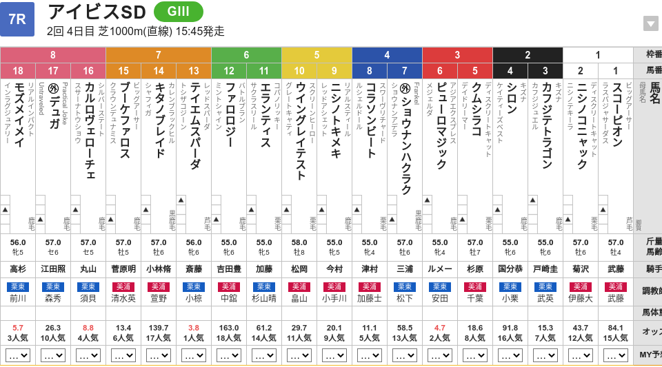

### 【クイーンステークス 2025/08/03(日) 】

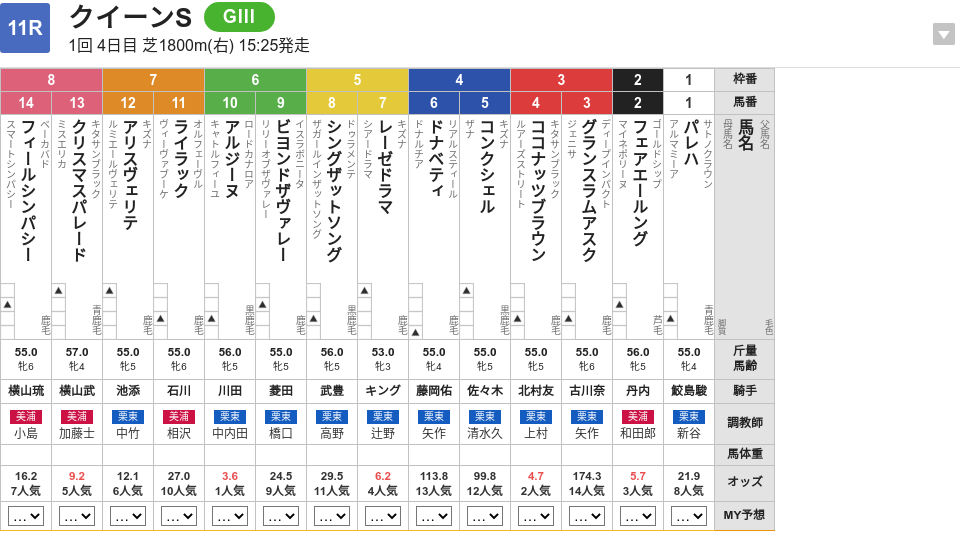

## 4. 単勝予測結果

### 【アイビスサマーD(GⅢ) 2025/08/03(日)】

| 枠番 | 馬番 | 人気 | オッズ | 馬名 | 騎手 | 調教師 | 予測タイム(sec) | 1_順位 | 1-3着内確率(%) | 2_順位 | ﾀﾞｰｸﾎｰｽ確率(%) | 3_順位 |
| --- | --- | --- | --- | --- | --- | --- | --- | --- | --- | --- | --- | --- |
| 1 | 1 | 15 | 83.3 | スコーピオン | 武藤雅 | 武藤善則 | 55.7 | 2.0 | 8.9 | 9 | 38.4 | 2 |
| 1 | 2 | 12 | 43.4 | ニシノコニャック | 菊沢一樹 | 伊藤大士 | 56.2 | 4.5 | 9.9 | 8 | 36.6 | 3 |
| 2 | 3 | 7 | 15.4 | カフジテトラゴン | 戸崎圭太 | 武英智 | 59.3 | 15.0 | 17.1 | 6 | 2.0 | 11 |
| 2 | 4 | 16 | 89.6 | シロン | 国分恭介 | 小栗実 | 56.1 | 3.0 | 8.6 | 10 | 40.1 | 1 |
| 3 | 5 | 8 | 18.8 | クムシラコ | 杉原誠人 | 千葉直人 | 58.3 | 11.0 | 19.8 | 5 | 2.1 | 10 |
| 3 | 6 | 2 | 4.7 | ピューロマジック | Ｃ．ルメール | 安田翔伍 | 57.7 | 8.0 | 21.0 | 4 | 0.4 | 18 |
| 4 | 7 | 13 | 60.4 | ショウナンハクラク | 三浦皇成 | 松下武士 | 58.0 | 9.0 | 3.7 | 17 | 10.8 | 8 |
| 4 | 8 | 5 | 11.1 | コラソンビート | 津村明秀 | 加藤士津八 | 57.3 | 7.0 | 24.5 | 2 | 1.6 | 13 |
| 5 | 9 | 9 | 19.7 | ニシノトキメキ | 今村聖奈 | 小手川準 | 58.2 | 10.0 | 6.6 | 14 | 0.8 | 15 |
| 5 | 10 | 11 | 29.6 | ウイングレイテスト | 松岡正海 | 畠山吉宏 | 61.7 | 18.0 | 5.8 | 16 | 17.8 | 6 |

[output cut: 8 more lines]

### 【クイーンステークス(GⅢ) 2025/08/03(日)】

| 枠番 | 馬番 | 人気 | オッズ | 馬名 | 騎手 | 調教師 | 予測タイム(sec) | 1_順位 | 1-3着内確率(%) | 2_順位 | ﾀﾞｰｸﾎｰｽ確率(%) | 3_順位 |
| --- | --- | --- | --- | --- | --- | --- | --- | --- | --- | --- | --- | --- |
| 1 | 1 | 8 | 21.9 | パレハ | 鮫島克駿 | 新谷功一 | 112.7 | 11 | 7.3 | 10 | 20.1 | 4 |
| 2 | 2 | 3 | 5.7 | フェアエールング | 丹内祐次 | 和田正一郎 | 111.5 | 7 | 14.8 | 5 | 0.4 | 14 |
| 3 | 3 | 14 | 173.7 | グランスラムアスク | 古川奈穂 | 矢作芳人 | 111.8 | 8 | 3.7 | 14 | 12.9 | 5 |
| 3 | 4 | 2 | 4.6 | ココナッツブラウン | 北村友一 | 上村洋行 | 110.6 | 5 | 38.7 | 2 | 0.4 | 12 |
| 4 | 5 | 12 | 101.1 | コンクシェル | 佐々木大輔 | 清水久詞 | 113.5 | 12 | 8.3 | 9 | 9.6 | 6 |
| 4 | 6 | 13 | 115.2 | ドナベティ | 藤岡佑介 | 矢作芳人 | 112.7 | 10 | 7.2 | 11 | 41.5 | 2 |
| 5 | 7 | 4 | 6.2 | レーゼドラマ | Ｒ．キング | 辻野泰之 | 109.1 | 2 | 43.5 | 1 | 0.4 | 13 |
| 5 | 8 | 11 | 30.1 | シングザットソング | 武豊 | 高野友和 | 114.9 | 14 | 5.2 | 13 | 45.6 | 1 |
| 6 | 9 | 9 | 24.9 | ビヨンドザヴァレー | 菱田裕二 | 橋口慎介 | 109.5 | 3 | 10.3 | 7 | 29.6 | 3 |
| 6 | 10 | 1 | 3.6 | アルジーヌ | 川田将雅 | 中内田充正 | 105.7 | 1 | 13.4 | 6 | 0.5 | 11 |

[output cut: 4 more lines]

## 5. 人気と着順の乖離率推移

### 【アイビスサマーD_2001y_2019y】

[interactive chart not shown]

### 【クイーンステークス_1990y_2019y】

[interactive chart not shown]

### 【アイビスサマーD_2001y_2019y】

| No | 開催年 | 不整合率(%) | 頭数 | 人気別着順(1-3位) | 人気別着順(全体) |
| --- | --- | --- | --- | --- | --- |
| 19 | 2019 | 27.5 | 18頭 | 1-3-9 | 1\|3\|9\|16\|4\|2\|7\|10\|13\|11\|8\|18\|15\|5\|6\|17\|14\|12 |
| 18 | 2018 | 21.9 | 17頭 | 1-2-8 | 1\|2\|8\|4\|9\|6\|10\|14\|13\|5\|3\|12\|17\|16\|15\|11\|7 |
| 17 | 2017 | 24.7 | 16頭 | 8-1-4 | 8\|1\|4\|2\|14\|6\|16\|7\|12\|3\|5\|15\|9\|11\|10\|13 |
| 16 | 2016 | 4.5 | 13頭 | 1-2-3 | 1\|2\|3\|4\|6\|5\|8\|10\|9\|11\|13\|12\|7 |
| 15 | 2015 | 22.7 | 14頭 | 1-9-4 | 1\|9\|4\|2\|5\|7\|6\|3\|8\|13\|14\|11\|10\|12 |
| 14 | 2014 | 30.0 | 12頭 | 1-5-3 | 1\|5\|3\|7\|8\|11\|2\|4\|12\|10\|6\|9 |
| 13 | 2013 | 30.3 | 18頭 | 1-3-6 | 1\|3\|6\|8\|12\|11\|4\|13\|17\|2\|5\|16\|14\|18\|15\|9\|7\|10 |
| 12 | 2012 | 71.5 | 18頭 | 7-5-4 | 7\|5\|4\|3\|6\|12\|14\|17\|2\|1\|13\|9\|16\|8\|15\|10\|18\|11 |
| 11 | 2011 | 36.3 | 15頭 | 1-5-11 | 1\|5\|11\|7\|3\|4\|6\|8\|10\|13\|2\|9\|12\|14\|15 |
| 10 | 2010 | 68.5 | 18頭 | 8-3-16 | 8\|3\|16\|6\|10\|12\|13\|5\|9\|2\|15\|14\|17\|4\|7\|18\|11\|1 |

[output cut: 9 more lines]

### 【クイーンステークス_1990y_2019y】

| No | 開催年 | 不整合率(%) | 頭数 | 人気別着順(1-3位) | 人気別着順(全体) |
| --- | --- | --- | --- | --- | --- |
| 30 | 2019 | 40.9 | 14頭 | 1-5-9 | 1\|5\|9\|4\|8\|3\|2\|7\|12\|10\|14\|13\|11\|6 |
| 29 | 2018 | 27.3 | 11頭 | 1-4-2 | 1\|4\|2\|7\|9\|8\|6\|10\|5\|3\|11 |
| 28 | 2017 | 36.9 | 13頭 | 2-6-8 | 2\|6\|8\|5\|10\|1\|3\|12\|7\|4\|13\|11\|9 |
| 27 | 2016 | 33.1 | 13頭 | 9-1-11 | 9\|1\|11\|8\|5\|6\|10\|2\|4\|3\|13\|7\|12 |
| 26 | 2015 | 47.3 | 10頭 | 7-1-4 | 7\|1\|4\|6\|5\|8\|3\|2\|9\|10 |
| 25 | 2014 | 25.6 | 14頭 | 2-6-1 | 2\|6\|1\|9\|3\|8\|4\|13\|5\|11\|7\|14\|10\|12 |
| 24 | 2013 | 21.0 | 8頭 | 1-8-3 | 1\|8\|3\|2\|4\|6\|7\|5 |
| 23 | 2012 | 31.2 | 14頭 | 1-10-4 | 1\|10\|4\|3\|2\|14\|8\|5\|13\|7\|9\|11\|12\|6 |
| 22 | 2011 | 29.3 | 14頭 | 1-10-3 | 1\|10\|3\|6\|4\|2\|5\|14\|12\|13\|11\|8\|9\|7 |
| 21 | 2010 | 46.5 | 14頭 | 2-3-6 | 2\|3\|6\|7\|5\|11\|4\|1\|9\|10\|13\|8\|12\|14 |

[output cut: 20 more lines]

## 6. 1-3番人気馬の着順分類予測

### 【アイビスサマーD】

| 分類 | 凡例 | 発生確率(%) | 当該レース | 当該レースランク | 直近1年間 |
| --- | --- | --- | --- | --- | --- |
| 1: 1番人気のみ (1_pop1) | 1 \| * \| * | 17.6 | 1.05 | 0.65 | 0.35 |
| 4: 1,2番人気のみ (4_pop12) | 1 \| 2 \| * | 16.5 | 1.32 | 0.81 | 0.00 |
| 5: 1,3番人気のみ (5_pop13) | 1 \| 3 \| * | 15.5 | 0.41 | 0.70 | 0.31 |
| 8: 1,2,3番人気すべて着外 (8_darkhorse) | * \| * \| * | 14.2 | 1.14 | 2.09 | 0.00 |
| 6: 2,3番人気のみ (6_pop23) | 2 \| 3 \| * | 9.9 | 2.36 | 1.46 | 0.00 |
| 2: 2番人気のみ (2_pop2) | 2 \| * \| * | 9.8 | 1.18 | 1.15 | 0.00 |
| 3: 3番人気のみ (3_pop3) | 3 \| * \| * | 9.4 | 2.24 | 1.38 | 0.00 |
| 7: 1,2,3番人気すべて着内 (7_pop123) | 1 \| 2 \| 3 | 7.1 | 1.69 | 4.18 | 0.00 |

### 【クイーンステークス】

| 分類 | 凡例 | 発生確率(%) | 当該レース | 当該レースランク | 直近1年間 |
| --- | --- | --- | --- | --- | --- |
| 1: 1番人気のみ (1_pop1) | 1 \| * \| * | 17.8 | 0.52 | 0.66 | 0.36 |
| 4: 1,2番人気のみ (4_pop12) | 1 \| 2 \| * | 16.7 | 0.65 | 0.82 | 0.00 |
| 8: 1,2,3番人気すべて着外 (8_darkhorse) | * \| * \| * | 14.5 | 5.00 | 2.13 | 0.00 |
| 5: 1,3番人気のみ (5_pop13) | 1 \| 3 \| * | 14.3 | 1.25 | 0.65 | 0.29 |
| 6: 2,3番人気のみ (6_pop23) | 2 \| 3 \| * | 10.0 | 1.16 | 1.47 | 0.00 |
| 2: 2番人気のみ (2_pop2) | 2 \| * \| * | 9.9 | 1.15 | 1.16 | 0.00 |
| 3: 3番人気のみ (3_pop3) | 3 \| * \| * | 9.5 | 1.10 | 1.40 | 0.00 |
| 7: 1,2,3番人気すべて着内 (7_pop123) | 1 \| 2 \| 3 | 7.2 | 0.00 | 4.24 | 0.00 |

## 7. 3連複予測結果

### 【アイビスサマーD(GⅢ) 2025/08/03(日)】

| 分類 | 馬番 | 枠番 | 人気 | 平均予測タイム(sec) | 1-3着内確率(%) | ﾀﾞｰｸﾎｰｽ確率(%) | 馬名 | 騎手 | 調教師 |
| --- | --- | --- | --- | --- | --- | --- | --- | --- | --- |
| 3: 3番人気のみ (3_pop3) | 18-16-8 | 8-8-4 | 3-4-5 | 58.50 | 2.59 | 0.00 | モズメイメイ \| カルロヴェローチェ \| コラソンビート | 高杉吏麒 \| 丸山元気 \| 津村明秀 | 前川恭子 \| 須貝尚介 \| 加藤士津八 |
| 6: 2,3番人気のみ (6_pop23) | 6-18-8 | 3-8-4 | 2-3-5 | 58.13 | 2.42 | 0.00 | ピューロマジック \| モズメイメイ \| コラソンビート | Ｃ．ルメール \| 高杉吏麒 \| 津村明秀 | 安田翔伍 \| 前川恭子 \| 加藤士津八 |
| 3: 3番人気のみ (3_pop3) | 18-8-5 | 8-4-3 | 3-5-8 | 58.33 | 2.28 | 0.00 | モズメイメイ \| コラソンビート \| クムシラコ | 高杉吏麒 \| 津村明秀 \| 杉原誠人 | 前川恭子 \| 加藤士津八 \| 千葉直人 |
| 6: 2,3番人気のみ (6_pop23) | 6-18-16 | 3-8-8 | 2-3-4 | 58.63 | 2.22 | 0.00 | ピューロマジック \| モズメイメイ \| カルロヴェローチェ | Ｃ．ルメール \| 高杉吏麒 \| 丸山元気 | 安田翔伍 \| 前川恭子 \| 須貝尚介 |
| 3: 3番人気のみ (3_pop3) | 18-16-5 | 8-8-3 | 3-4-8 | 58.83 | 2.09 | 0.00 | モズメイメイ \| カルロヴェローチェ \| クムシラコ | 高杉吏麒 \| 丸山元気 \| 杉原誠人 | 前川恭子 \| 須貝尚介 \| 千葉直人 |
| 3: 3番人気のみ (3_pop3) | 18-8-3 | 8-4-2 | 3-5-7 | 58.67 | 1.97 | 0.00 | モズメイメイ \| コラソンビート \| カフジテトラゴン | 高杉吏麒 \| 津村明秀 \| 戸崎圭太 | 前川恭子 \| 加藤士津八 \| 武英智 |
| 6: 2,3番人気のみ (6_pop23) | 6-18-5 | 3-8-3 | 2-3-8 | 58.47 | 1.95 | 0.00 | ピューロマジック \| モズメイメイ \| クムシラコ | Ｃ．ルメール \| 高杉吏麒 \| 杉原誠人 | 安田翔伍 \| 前川恭子 \| 千葉直人 |
| 3: 3番人気のみ (3_pop3) | 18-16-3 | 8-8-2 | 3-4-7 | 59.17 | 1.80 | 0.00 | モズメイメイ \| カルロヴェローチェ \| カフジテトラゴン | 高杉吏麒 \| 丸山元気 \| 戸崎圭太 | 前川恭子 \| 須貝尚介 \| 武英智 |
| 6: 2,3番人気のみ (6_pop23) | 6-18-3 | 3-8-2 | 2-3-7 | 58.80 | 1.68 | 0.00 | ピューロマジック \| モズメイメイ \| カフジテトラゴン | Ｃ．ルメール \| 高杉吏麒 \| 戸崎圭太 | 安田翔伍 \| 前川恭子 \| 武英智 |
| 3: 3番人気のみ (3_pop3) | 18-3-5 | 8-2-3 | 3-7-8 | 59.00 | 1.59 | 0.00 | モズメイメイ \| カフジテトラゴン \| クムシラコ | 高杉吏麒 \| 戸崎圭太 \| 杉原誠人 | 前川恭子 \| 武英智 \| 千葉直人 |

[output cut: 806 more lines]

### 【クイーンステークス(GⅢ) 2025/08/03(日)】

| 分類 | 馬番 | 枠番 | 人気 | 平均予測タイム(sec) | 1-3着内確率(%) | ﾀﾞｰｸﾎｰｽ確率(%) | 馬名 | 騎手 | 調教師 |
| --- | --- | --- | --- | --- | --- | --- | --- | --- | --- |
| 2: 2番人気のみ (2_pop2) | 4-7-13 | 3-5-8 | 2-4-5 | 109.90 | 3.97 | 0.00 | ココナッツブラウン \| レーゼドラマ \| クリスマスパレード | 北村友一 \| Ｒ．キング \| 横山武史 | 上村洋行 \| 辻野泰之 \| 加藤士津八 |
| 2: 2番人気のみ (2_pop2) | 4-7-14 | 3-5-8 | 2-4-7 | 110.40 | 3.64 | 0.00 | ココナッツブラウン \| レーゼドラマ \| フィールシンパシー | 北村友一 \| Ｒ．キング \| 横山琉人 | 上村洋行 \| 辻野泰之 \| 小島茂之 |
| 6: 2,3番人気のみ (6_pop23) | 4-2-7 | 3-2-5 | 2-3-4 | 110.40 | 2.48 | 0.00 | ココナッツブラウン \| フェアエールング \| レーゼドラマ | 北村友一 \| 丹内祐次 \| Ｒ．キング | 上村洋行 \| 和田正一郎 \| 辻野泰之 |
| 4: 1,2番人気のみ (4_pop12) | 10-4-7 | 6-3-5 | 1-2-4 | 108.47 | 2.26 | 0.00 | アルジーヌ \| ココナッツブラウン \| レーゼドラマ | 川田将雅 \| 北村友一 \| Ｒ．キング | 中内田充正 \| 上村洋行 \| 辻野泰之 |
| 8: 1,2,3番人気すべて着外 (8_darkhorse) | 7-13-14 | 5-8-8 | 4-5-7 | 110.20 | 2.22 | 0.00 | レーゼドラマ \| クリスマスパレード \| フィールシンパシー | Ｒ．キング \| 横山武史 \| 横山琉人 | 辻野泰之 \| 加藤士津八 \| 小島茂之 |
| 2: 2番人気のみ (2_pop2) | 4-13-14 | 3-8-8 | 2-5-7 | 110.70 | 1.97 | 0.00 | ココナッツブラウン \| クリスマスパレード \| フィールシンパシー | 北村友一 \| 横山武史 \| 横山琉人 | 上村洋行 \| 加藤士津八 \| 小島茂之 |
| 2: 2番人気のみ (2_pop2) | 4-7-9 | 3-5-6 | 2-4-9 | 109.73 | 1.73 | 0.00 | ココナッツブラウン \| レーゼドラマ \| ビヨンドザヴァレー | 北村友一 \| Ｒ．キング \| 菱田裕二 | 上村洋行 \| 辻野泰之 \| 橋口慎介 |
| 2: 2番人気のみ (2_pop2) | 4-7-12 | 3-5-7 | 2-4-6 | 111.43 | 1.71 | 0.00 | ココナッツブラウン \| レーゼドラマ \| アリスヴェリテ | 北村友一 \| Ｒ．キング \| 池添謙一 | 上村洋行 \| 辻野泰之 \| 中竹和也 |
| 3: 3番人気のみ (3_pop3) | 2-7-13 | 2-5-8 | 3-4-5 | 110.20 | 1.51 | 0.00 | フェアエールング \| レーゼドラマ \| クリスマスパレード | 丹内祐次 \| Ｒ．キング \| 横山武史 | 和田正一郎 \| 辻野泰之 \| 加藤士津八 |
| 2: 2番人気のみ (2_pop2) | 4-7-5 | 3-5-4 | 2-4-12 | 111.07 | 1.39 | 0.00 | ココナッツブラウン \| レーゼドラマ \| コンクシェル | 北村友一 \| Ｒ．キング \| 佐々木大輔 | 上村洋行 \| 辻野泰之 \| 清水久詞 |

[output cut: 354 more lines]

## 8. 直近の全レース情報

[output not shown]